# Updating Gain drift module in TOAST

```python
from IPython.display import HTML

HTML('''<script>
code_show=true;
function code_toggle() {
 if (code_show){
 $('div.input').hide();
 } else {
 $('div.input').show();
 }
 code_show = !code_show
}
$( document ).ready(code_toggle);
</script>
<form action="javascript:code_toggle()"><input type="submit" value="Click here to toggle on/off the raw code."></form>''')
```

```python
import pylab as pl
from  numpy.random import normal
import numpy as np
import healpy as hp
import scipy
from scipy  import  signal, special , stats
from scipy.signal import periodogram

from pylab import cm
cmap = cm.get_cmap('RdYlBu')
cmap.set_under('w')
import scipy.stats as spt
from scipy import interpolate

import warnings; warnings.simplefilter('ignore')
warnings.simplefilter('ignore', DeprecationWarning)

def bin_gains(tau, fs,obs,  g) :
    sizech = pl.int_( tau *fs)  ; nch =pl.int_(  obs *fs*3600  /sizech)
    gb = pl.zeros(nch)
    for i in range (nch):
        gb[i] =g[slice(i*sizech, (i+1)*sizech)] .mean()
    return gb
```

```python
def showperpair(Pair,folder , obs = 1 ):
    fs = 19
    fsat = 0.05/60 /2/pl.pi
    l_of_f =lambda freq:  freq / ( fsat *pl.sin(pl.deg2rad(50)) )
    tau10=600
    factor = {0:1., 1:-1 }
    #folder = '/Users/peppe/work/satellite_sims/driftruns/fknee10/'
    dri = pl.array( [pl.load(folder+'tot_signal_M03_030_QB_140B.npy') ,
         pl.load(folder+'tot_signal_M03_030_QB_140T.npy')] ) [:,  :pl.int_( fs*3600*obs )]
    if factor[Pair]==1  :
        sig  = pl.array([pl.load(folder+'template_M03_030_QB_140B.npy') ,
         pl.load(folder+'template_M03_030_QB_140T.npy') ]) [:,  :pl.int_( fs*3600*obs )]
    else:
        sig = pl.array([pl.load(folder+'signal_M03_030_QB_140B.npy') ,
             pl.load(folder+'signal_M03_030_QB_140T.npy') ]) [:,  :pl.int_( fs*3600*obs )]

    mit = pl.array([pl.load(folder+'mit_tot_signal_M03_030_QB_140B.npy') ,
         pl.load(folder+'mit_tot_signal_M03_030_QB_140T.npy')]) [:,  :pl.int_( fs*3600*obs )]

    factor = {0:1., 1:-1 }
    dicx = {  0:'sum',  1:'diff'   }


    sums =.5* ( sig[0,:]   + (factor[Pair] *sig[1,: ]) )


    sumd =.5* ( dri[0,:] +(factor[Pair] * dri[1,: ]))
    summ =.5* ( mit [0,:] +(factor[Pair] * mit[1,: ]) )


    t=  pl.arange(len(summ))/3600. /fs

    fig = pl.figure(figsize=(16,4) )
    ax1 = fig.add_subplot(121);
    pl.title( 'Pair %s'%dicx[Pair]  )

    pl.ylabel('TOD [K]')


    f,pds= periodogram( sums ,fs=fs, scaling='density', window='triang')
    f,pd= periodogram(  (  sumd)
                  ,fs=fs, scaling='density', window='triang')
    f,pdc  = periodogram(  (  summ),  fs=fs, scaling='density', window='triang')

    ax1.plot(t,  (  sums)   , label='Pair %s signal'%dicx[Pair]    );
    ax1.plot(t, (  sumd   )      ,alpha=.5 , label='Pair %s w/ Drift '%dicx[Pair]  );
    #ax1.plot(t,   .5* ( filt[0,:] +(factor[Pair] * filt[1,: ]))      ,alpha=.5 , label='Pair %s w/ Drift (x0.1)'%dicx[Pair]  );

    ax1.plot(t,  (  summ),alpha=.5 , label='Pair %s post-mitigat.'%dicx[Pair]);

    pl.legend()
    pl.xlabel('t [h]')

    pl.xlim(0,5)

    pl.subplot(122)

    ax1 = fig.add_subplot(122);
    ax2 = ax1.twiny() ;

    ax2.set_xlabel(r'$\ell$', fontsize=15);
    ax1.set_xlabel('frequency  [Hz] ', fontsize=15);
    ax1.set_ylabel('PSD ['+r'$K \sqrt{s}$]', fontsize=15)
    #pl.subplot(122)

    ax1.loglog(f , pl.sqrt(pds)  , label='Pair  %s Signal-only '%dicx[Pair] )
    ax1.loglog(f , pl.sqrt(pd),  alpha=.6, label='Pair %s w/ Drift'%dicx[Pair] )



    ax1.loglog(f , pl.sqrt(pdc) ,  alpha=.5 , label='Pair %s Signal post-mitigat.'%dicx[Pair] )
    #ax1.loglog(freq, pl.sqrt(fspectrum),     alpha=.5
    #           , color='black' , label='CMB '  )
    ax1.loglog(f , pl.ones_like(f )*50e-6,'r--', alpha=.3, linewidth=3, label='NET ' )
    ax2.loglog(l_of_f(f) , pl.zeros_like(f ) );
    ax1.legend()

    ax1.grid()

    pl.ylim((1e-10,1e2))


    #pl.loglog(f , pl.sqrt(pds) , label='Pair  %s Signal-only '%dicx[Pair])
    #pl.loglog(f , pl.sqrt(pd),   alpha=.8 , label='Pair %s w/ Drift'%dicx[Pair])
    #pl.loglog(f , pl.sqrt(pdf),   alpha=.6 , label='Pair Sum Signal w/ Drift HPF ')

    #pl.loglog(f , pl.sqrt(pdc) ,  alpha=.6 , label='Pair %s Signal w/ Mitigat.'%dicx[Pair])
    #pl.grid(True, alpha=.4 )
    #pl.legend()
```

## Outline

several improvements have been implemented in the gain drifter module in TOAST :

1. **Making drifts more realistic.** I aim at reducing the typical time scale scale of the drifts (see e.g. https://wiki.kek.jp/display/~gpuglisi/Gain+Drifts+Systematics). Now the drift fluctuates at scales comparable to the observation one (frequencies larger than the observation period are not accounted).
2. **Reducing the jumps** between two neighbour gain estimation intervals(see image below).

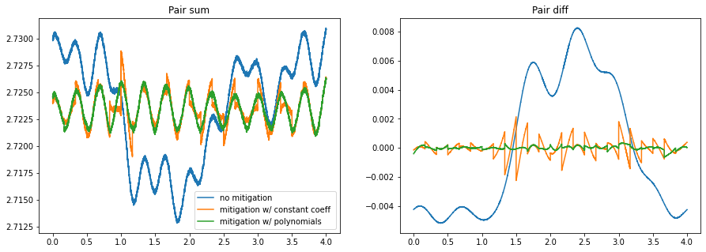

   I use a moving window, including a partial overlap (1 min ) between two neighbour intervals of 10 min.
3. **Improving the regression.** Before I simply estimated the linear regression coefficient between the template and the drifted TOD(which corresponds to 0th order poly), now I estimate also the coefficients for the 1st and 2nd order polynomial as if follows:

$$ d_{A} = g_A(t) (s_{T} + s_{P} )+ n \\ T =s_{template} \\ f(t, \alpha ) = \sum _i \alpha_i \mathcal{P_L^{(i)}} (t) \\ \hat{\alpha} = LinRegress (f, T, d_{A}) \\ \hat{G}(t) = \sum _i \hat{\alpha}_i \mathcal{P_L^{(i)}} (t) \\ \tilde{d} = d/\hat{G} $$

I tested the mitigation for different choices of templates on 12 h of LB observations and a common set of parameters :

- fknee_drift= 50 mHz
- gain fluctuation amplitude = 1e-2 (wich should corresponds to 10 uK, to be checked with Dominic)

Simulation Pipeline :

1. generate TODs from scanning the input signal and template maps
2. inject gain drift to the signal TOD
3. coadd instrumental noise to the signal TOD
4. Mitigate gain drift with CMB T by *HPF filtering* the signal +noise TOD, estimate the gain, mitigated the **unfiltered** TOD.
5. Run the destriper, etc..

## CMB T template

- input = Dipole + CMB
- template = CMB T

params=" --obs-time-h 12 --obs-num 1 \ --hardware /Users/peppe/work/satellite_sims/hardware/M03_030_QB_140.toml.gz \ --bands M1-140 --sample-rate 19. \ --spin-period-min 20.0 --spin-angle-deg 50 \ --prec-period-min 192.34 --prec-angle-deg 45. \ --nside 256 \ --no-madam \ --madam-baseline-length 60 \ --coord G \ --hwp-rpm 0. --MC-start 0 --MC-count 1 \ --dipole \ --template-map /Users/peppe/work/satellite_sims/maps/CMB_TnoQU_256.fits \ --input-map /Users/peppe/work/satellite_sims/maps/CMB_TQU_256.fits \ --outdir cmbT \ --fknee-drift 0.05 \ --gain-sigma 1e-2 \ --no-pysm-apply-beam \ --drift-gains \ --mitigate-gaindrifts \ --poly-order 2 --polyfilter \ --debug \ --noise "

[output not shown]

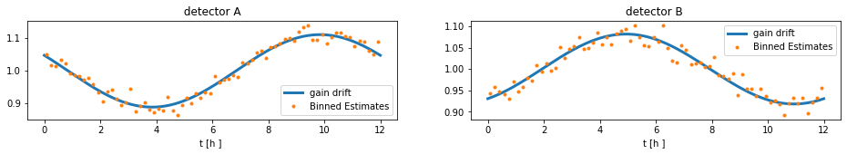

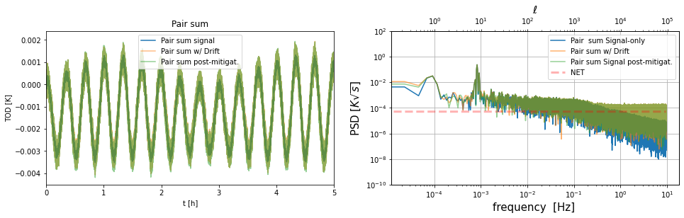

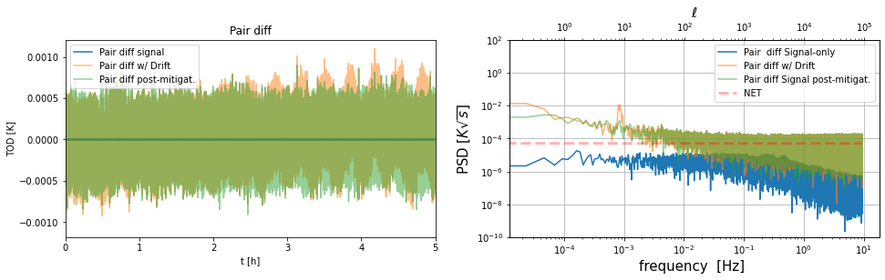

```python
pl.figure(figsize=(16,2))
obs=12
folder = '/Users/peppe/work/satellite_sims/driftruns/cmbT/'
tau10 =600
fs=19
gi=pl.load(folder+ 'gain_drift.npy')
ge  = pl.load(folder+'gains_coeff_'+str(tau10)+'.npy')
t=  pl.arange(gi.shape[1])/3600. /fs
tb = bin_gains(tau=tau10, fs=fs ,obs=obs ,  g=t )
for jj in range(ge.shape[0]):
    pl.subplot(121+jj)
    if jj==0 :
        pl.title(' detector A ')
    else:
        pl.title('detector B ')
    pl.plot(t, (  gi[jj]  )  ,  lw=3,  label='gain drift ')
    pl.plot(tb, bin_gains(tau=tau10, fs=fs ,obs=obs ,  g=ge[jj] ),'.', label = 'Binned Estimates' )
    pl.xlabel('t [h ] ')
    pl.legend()

showperpair(0,folder=folder , obs = 12 )
showperpair(1,folder=folder  , obs = 12 )
```

## Dipole template

- input = Dipole + CMB
- template = Dipole

params=" --obs-time-h 12 --obs-num 1 \ --hardware /Users/peppe/work/satellite_sims/hardware/M03_030_QB_140.toml.gz \ --bands M1-140 --sample-rate 19. \ --spin-period-min 20.0 --spin-angle-deg 50 \ --prec-period-min 192.34 --prec-angle-deg 45. \ --nside 256 \ --no-madam \ --madam-baseline-length 60 \ --coord G \ --hwp-rpm 0. --MC-start 0 --MC-count 1 \ --dipole \ --template-map /Users/peppe/work/satellite_sims/maps/CMB_TnoQU_256.fits \ --input-map /Users/peppe/work/satellite_sims/maps/CMB_TQU_256.fits \ --outdir dipole \ --fknee-drift 0.05 \ --gain-sigma 1e-2 \ --no-pysm-apply-beam \ --drift-gains \ --mitigate-gaindrifts \ --debug \ --noise  
"

```
(2, 820800)
```

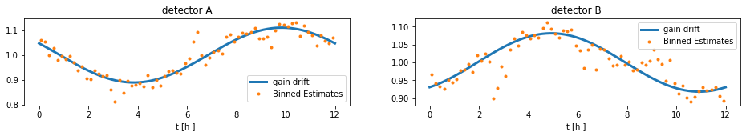

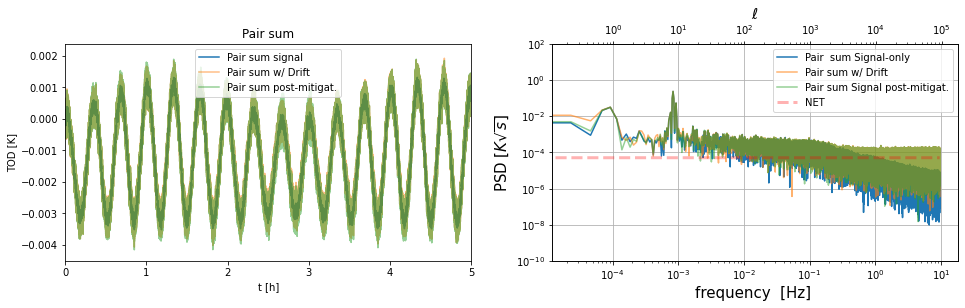

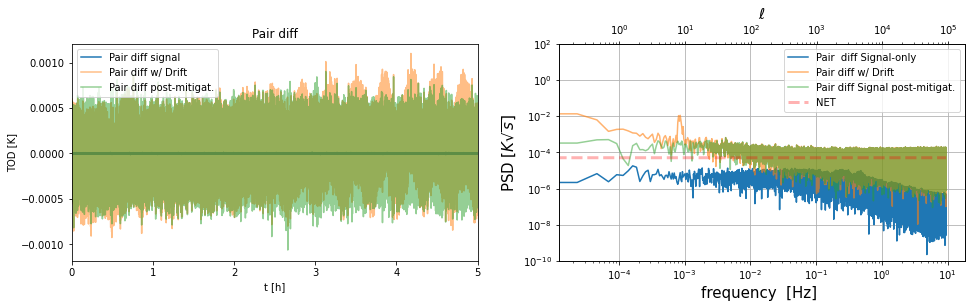

```python
pl.figure(figsize=(16,2))
obs=12
folder = '/Users/peppe/work/satellite_sims/driftruns/dipole/'
tau10 =600
fs=19
gi=pl.load(folder+ 'gain_drift.npy')
ge  = pl.load(folder+'gains_coeff_'+str(tau10)+'.npy')
t=  pl.arange(gi.shape[1])/3600. /fs
tb = bin_gains(tau=tau10, fs=fs ,obs=obs ,  g=t )

print(ge.shape)
for jj in range(ge.shape[0]):
    pl.subplot(121+jj)
    if jj==0 :
        pl.title(' detector A ')
    else:
        pl.title('detector B ')
    pl.plot(t, (  gi[jj]  )  ,  lw=3,  label='gain drift ')
    pl.plot(tb, bin_gains(tau=tau10, fs=fs ,obs=obs ,  g=ge[jj] ),'.', label = 'Binned Estimates' )
    pl.xlabel('t [h ] ')
    pl.legend()

showperpair(0,folder=folder , obs = 12 )
showperpair(1,folder=folder  , obs = 12 )
```

## Accounting for monopole

- input = Monopole + Dipole + CMB
- template = Dipole

params=" --obs-time-h 12 --obs-num 1 \ --hardware /Users/peppe/work/satellite_sims/hardware/M03_030_QB_140.toml.gz \ --bands M1-140 --sample-rate 19. \ --spin-period-min 20.0 --spin-angle-deg 50 \ --prec-period-min 192.34 --prec-angle-deg 45. \ --nside 256 \ --no-madam \ --madam-baseline-length 60 \ --coord G \ --hwp-rpm 0. --MC-start 0 --MC-count 1 \ --dipole \ --template-map /Users/peppe/work/satellite_sims/maps/CMB_TnoQU_256.fits \ --input-map /Users/peppe/work/satellite_sims/maps/CMB_TQU_256.fits \ --outdir monopole \ --fknee-drift 0.05 \ --gain-sigma 1e-2 \ --no-pysm-apply-beam \ --drift-gains \ --mitigate-gaindrifts \ --debug \ --noise \ --add-monopole "

```
(2, 820800)
```

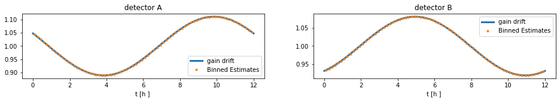

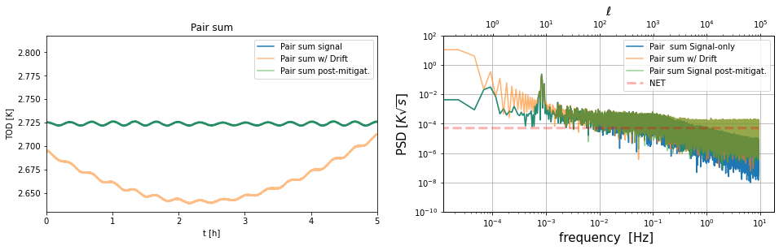

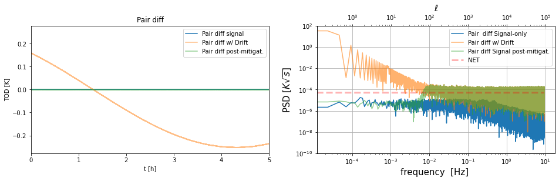

```python
pl.figure(figsize=(16,2))
obs=12
folder = '/Users/peppe/work/satellite_sims/driftruns/monopole/'
tau10 =600
fs=19
gi=pl.load(folder+ 'gain_drift.npy')
ge  = pl.load(folder+'gains_coeff_'+str(tau10)+'.npy')
t=  pl.arange(gi.shape[1])/3600. /fs
tb = bin_gains(tau=tau10, fs=fs ,obs=obs ,  g=t )

print(ge.shape)
for jj in range(ge.shape[0]):
    pl.subplot(121+jj)
    if jj==0 :
        pl.title(' detector A ')
    else:
        pl.title('detector B ')
    pl.plot(t, (  gi[jj]  )  ,  lw=3,  label='gain drift ')
    pl.plot(tb, bin_gains(tau=tau10, fs=fs ,obs=obs ,  g=ge[jj] ),'.', label = 'Binned Estimates' )
    pl.xlabel('t [h ] ')
    pl.legend()

showperpair(0,folder=folder , obs = 12 )
showperpair(1,folder=folder  , obs = 12 )
```